# Praca domowa 1

Jakub Zbrzezny

6 listopada 2019

source(“Kuboz46_Zbrzezny_Jakub_286689_pd1.R”)

# Zadanie 1

Dana funkcja przyjmuje macierz A wymiaru n x m. Oblicza macierz korelacji rozmiaru m x m taką, że na i-tym wierszu i j-tej kolumnie znajduje się liniowy współczynnik korelacji Pearsona pomiędzy i-tą kolumną i j-tą kolumną macierz A.

Funkcja korzysta z funkcji apply, colMeans. Wynikiem funkcji jest macierz B * C, gdzie B, C są macierzami pomocniczymi zdefiniowanymi następująco:

Na i-tym wierszu i j-tej kolumnie macierzy B jest różnica elementu macierzy A na j-tym wierszu i i-tej kolumnie, podzielona przez pierwiastek z sumy po wszystkich wierszach k z kwadratu różnicy elementu macierzy A na k-tym wierszu i i-tej kolumnie i średniej z elementów znajdujących się na i-tej kolumnie macierzy A.

Natomiast na i-tym wierszu i j-tej kolumnie macierzy D wartość jest analogiczna jak w przypadku macierzy B. Jedyna różnica jest taka, że w indeksach macierzy A zamieniamy i z j.

Z definicji mnożenia macierzy widać, że w macierzy wynikowej postać elementu jest zgodna z definicją liniowego współczynnika korelacji Pearsona.

Działanie tej funkcji sprawdzę na paru przykładach:

## Przykład 1

Dla macierzy A wymiaru 3 x 3:

```r
A <- matrix(c(16, 23, 3, 32, 46, 6, 4, 22, 16), nrow = 3)
A
```

```
##      [,1] [,2] [,3]
## [1,]   16   32    4
## [2,]   23   46   22
## [3,]    3    6   16
```

Wynik mamy następujący:

```r
macierz_korelacji(A)
```

```
##           [,1]      [,2]      [,3]
## [1,] 1.0000000 1.0000000 0.1612624
## [2,] 1.0000000 1.0000000 0.1612624
## [3,] 0.1612624 0.1612624 1.0000000
```

Widać, że wyniki wyglądają prawidłowo, gdyż łatwo zauważyć, że zależność między drugą, a pierwszą kolumną jest liniowa, ale między drugą, a trzecią już nie. Porównamy teraz naszą funkcję z wbudowaną funkcją cor:

```r
all.equal(cor(A,A), macierz_korelacji(A))
```

```
## [1] TRUE
```

Wynikiem jest TRUE, więc w tym przypadku funkcja działa poprawnie.

## Przykład 2

Teraz weźmiemy macierz wymiaru 5 x 3.

```r
A <- matrix(c(16, 23, 3, 32, 46, 6, 4, 22, 16, 35, 3, 3, 5, 5, 5), nrow = 5)
A
```

```
##      [,1] [,2] [,3]
## [1,]   16    6    3
## [2,]   23    4    3
## [3,]    3   22    5
## [4,]   32   16    5
## [5,]   46   35    5
```

Macierz korelacji wygląda następująco:

```r
macierz_korelacji(A)
```

```
##           [,1]      [,2]      [,3]
## [1,] 1.0000000 0.4678348 0.2530647
## [2,] 0.4678348 1.0000000 0.8376816
## [3,] 0.2530647 0.8376816 1.0000000
```

Sprawdźmy teraz poprawność funkcji.

```r
all.equal(cor(A,A), macierz_korelacji(A))
```

```
## [1] TRUE
```

W tym przypadku również jest TRUE, więc metoda działa prawidłowo.

## Przykład 3

A co, gdy wszystkie elementy w pewnej kolumnie są takie same?

```r
A <- matrix(c(16, 23, 3, 32, 46, 6, 4, 22, 16, 35, 3, 3, 5, 5, 5), nrow = 3)
A
```

```
##      [,1] [,2] [,3] [,4] [,5]
## [1,]   16   32    4   35    5
## [2,]   23   46   22    3    5
## [3,]    3    6   16    3    5
```

Macierz korelacji:

```r
macierz_korelacji(A)
```

```
##           [,1]      [,2]       [,3]       [,4] [,5]
## [1,] 1.0000000 1.0000000  0.1612624  0.1706640  NaN
## [2,] 1.0000000 1.0000000  0.1612624  0.1706640  NaN
## [3,] 0.1612624 0.1612624  1.0000000 -0.9449112  NaN
## [4,] 0.1706640 0.1706640 -0.9449112  1.0000000  NaN
## [5,]       NaN       NaN        NaN        NaN  NaN
```

Widać, że na 5 wierszu i 5 kolumnie wszystkie elementy są NaN. Spowodowane jest tym, że wariancja 5 kolumny macierzy A jest równa 0, gdyż wszystkie elementy w 5 kolumnie są równe.

Porównajmy wyniki naszej funkcji z wynikami zwracanymi przez wbudowaną funkcję cor.

```r
all.equal(cor(A,A), macierz_korelacji(A))
```

```
## Warning in cor(A, A): odchylenie standardowe wynosi zero
```

```
## [1] TRUE
```

Po wywołaniu powyższej komendy nie ma błędu, ale jest ostrzeżenie, które mówi, że w cor(A,A) pojawia się odchylenie standardowe równe zero. Mimo wszystko zwracana jest wartość TRUE, zatem i w takim przypadku działanie naszej funkcji jest poprawne.

Zatem metoda jest skuteczna.

# Zadanie 2

Dana funkcja zwraca dwuelementową listę zawierającą: 1. wektor zawierający średnie 3 najmniejszych elementów każdej kolumny, 2. macierz rozmiaru (n - 1) x m zawierającą średnie sąsiednich elementów w każdej kolumnie, przy czym sąsiadem elementu A[i, j] jest element A[i + 1, j].

Funkcja przyjmuje macierz M rozmiaru n x m (n > 3, m > 3). Najpierw tworzymy listę z dwóch pustych elementów.

Tworząc pierwszy element, korzystamy z funkcji colMeans dla posortowanych kolumn. Jako pierwszy element listy bierzemy cały 1, 2, 3 wiersz macierzy otrzymanej z funkcji colMeans.

Natomiast, tworząc drugi element listy, bierzemy macierz M1 będącą macierzą M z usuniętym n-tym wierszem i macierz M2, która jest macierzą M z usuniętym 1-szym wierszem. Jako drugi element listy bierzemy macierz 1/2 * (M1 + M2).

Sprawdzimy działanie tej funkcji na paru przykładach. ## Przykład 1

```r
A <- matrix(c(16, 23, 3, 32, 46, 6, 4, 22, 16, 3, 532, 23, 234, 23, 234, 5346), nrow = 4)
A
```

```
##      [,1] [,2] [,3] [,4]
## [1,]   16   46   16  234
## [2,]   23    6    3   23
## [3,]    3    4  532  234
## [4,]   32   22   23 5346
```

```r
podsumowanie(A)
```

```
## [[1]]
## [1]  14.00000  10.66667  14.00000 163.66667
##
## [[2]]
##      [,1] [,2]  [,3]   [,4]
## [1,] 19.5   26   9.5  128.5
## [2,] 13.0    5 267.5  128.5
## [3,] 17.5   13 277.5 2790.0
```

Widzimy, że wynik jest prawidłowy. ## Przykład 2

```r
A <- matrix(c(16, 23, 3, 32, 46, 6, 4, 22, 16, 35, 3, 3, 5, 5, 5, 24, 22, 21, 20), nrow = 5)
A
```

```
##      [,1] [,2] [,3] [,4]
## [1,]   16    6    3   24
## [2,]   23    4    3   22
## [3,]    3   22    5   21
## [4,]   32   16    5   20
## [5,]   46   35    5   16
```

```r
podsumowanie(A)
```

```
## [[1]]
## [1] 14.000000  8.666667  3.666667 19.000000
##
## [[2]]
##      [,1] [,2] [,3] [,4]
## [1,] 19.5  5.0    3 23.0
## [2,] 13.0 13.0    4 21.5
## [3,] 17.5 19.0    5 20.5
## [4,] 39.0 25.5    5 18.0
```

Tu metoda też działa poprawnie. ## Przykład 3

```r
A <- matrix(c(1050,1020, 1000, 800, 840, 820, 900, 920, 940, 900, 700, 550, 660, 210, 400, 10, 20, 22, 23, 24, 241, 231, 678, 638, 618), nrow = 5)
A
```

```
##      [,1] [,2] [,3] [,4] [,5]
## [1,] 1050  820  700   10  241
## [2,] 1020  900  550   20  231
## [3,] 1000  920  660   22  678
## [4,]  800  940  210   23  638
## [5,]  840  900  400   24  618
```

```r
podsumowanie(A)
```

```
## [[1]]
## [1] 880.00000 873.33333 386.66667  17.33333 363.33333
##
## [[2]]
##      [,1] [,2] [,3] [,4]  [,5]
## [1,] 1035  860  625 15.0 236.0
## [2,] 1010  910  605 21.0 454.5
## [3,]  900  930  435 22.5 658.0
## [4,]  820  920  305 23.5 628.0
```

Widać, że tu wyniki są także prawidłowe.

Stąd działanie naszej metody jest zadowalające.

# Zadanie 3

Wiemy, że:

Talia kart liczy 52 sztuk. W talii są cztery kolory: pik, kier, karo, trefl. Każdy z kolorów posiada 9 kart numerowanych: 2, 3, 4, 5, 6, 7, 8, 9, 10, 3 figury J, Q, K oraz Asa A. Gracz 1 ma na ręce 6 trefl i 1 J pik (wartość 16). Gracz 2 ma 2 karty, jedna z nich to K trefl, druga zaś nie jest widoczna. Teraz gracze mają możliwość dobrania jeszcze jednej karty. Gracz 2 zdecyduje, że nie dobiera więcej kart.

Liczba rozgrywek wynosi 1000.

## Przypadek 1: Gracz 1 nie wyciąga karty.

### Gracz 2 ma dwójkę jako drugą kartę.

Wtedy gracz 1 wygra.

### Gracz 2 ma trójkę jako drugą kartę.

Gracz 1 wygra.

### Gracz 2 ma piątkę jako drugą kartę.

Gracz 1 wygra.

### Gracz 2 ma szóstkę jako drugą kartę.

Tym razem gracz 1 nie wygra, bo jest remis.

### Gracz 2 ma siódemkę jako drugą kartę.

Gracz 1 przegra, więc nie wygra.

### Gracz 2 ma dziesiątkę jako drugą kartę.

Gracz 1 nie wygra.

### Gracz 2 ma figurę J.

Gracz 1 nie wygra.

### Gracz 2 ma figurę K.

Gracz 1 nie wygra.

### Gracz 2 ma Asa.

Gracz 1 nie wygra.

Zatem jest 16 możliwości na 44 sprzyjających zdarzeniu, że gracz 1 wygra. Możemy oszacować prawdopodobieństwo wygrania gracza 1, losując 1000 razy liczby ze zbioru {1, 2, 3, …, 44}. Wynikiem jest liczba wylosowanych elementów nie większych niż 16.

Szacowane prawdopodobieństwo liczymy za pomocą następującej komendy:

```r
n <- 1000
x <- ceiling(runif(n, 0, 44))
length(which(x <= 16)) / 1000
```

```
## [1] 0.374
```

## Przypadek 2: Gracz 1 wyciąga kartę.

### Gracz 1 wyciągnął dwójkę.

Wtedy ma 18 punktów.

Jeśli gracz 2 jako drugą kartę ma dwójkę, trójkę, … lub siódemkę, to gracz 1 wygrywa.

Gdy gracz 2 jako drugą kartę ma ósemkę, dziewiątkę lub dziesiątkę, to gracz 1 nie wygrywa.

Jeżeli gracz 2 jako drugą kartę ma figurę lub Asa, to też gracz 1 nie wygrywa.

Czyli jest (6 * 4 - 1) na 43 możliwości, gdzie gracz 1 wygra.

### Gracz 1 wyciągnął trójkę.

Wtedy ma 19 punktów.

Jest wtedy (7 * 4 - 1) na 43 możliwości, gdzie gracz 1 wygra.

### Gracz 1 wyciągnął czwórkę.

Wtedy ma 20 punktów.

Jest wtedy (8 * 4 - 1) na 43 możliwośći, gdzie gracz 1 wygra.

### Gracz 1 wyciągnął piątkę.

Wtedy ma 21 punktów.

### Gracz 1 wyciągnął szóstkę, siódemkę, …, lub dziesiątkę.

Gracz 1 nie wygra, bo ma co najmniej 22 > 21 punktów.

### Gracz 1 wyciągnął figurę.

Gracz 1 ma 26 > 21 punktów, więc przegra grę, czyli jej nie wygra.

### Gracz 1 wyciągnął Asa.

Gracz 1 ma 17 punktów.

Jest (5 * 4 - 1) na 43 możliwośći, gdzie gracz 1 wygra.

A zatem szacowanym prawdopodobieństwem jest średnia prawdopodobieństw wygrania gracza 1 z wszystkich przypadków wziętej karty przez gracza 1.

Liczymy je za pomocą następującego kodu:

```r
n <- 1000

pr <- rep(0,13)

x <- ceiling(runif(n, 0, 44))
pr[1] <- length(which(x <= 23)) / 1000

x <- ceiling(runif(n, 0, 44))
pr[2] <- length(which(x <= 27)) / 1000

x <- ceiling(runif(n, 0, 44))
pr[3] <- length(which(x <= 31)) / 1000

x <- ceiling(runif(n, 0, 44))
pr[4] <- length(which(x <= 35)) / 1000

x <- ceiling(runif(n, 0, 44))
pr[5] <- length(which(x <= 0)) / 1000
pr[6] <- length(which(x <= 0)) / 1000
pr[7] <- length(which(x <= 0)) / 1000
pr[8] <- length(which(x <= 0)) / 1000
pr[9] <- length(which(x <= 0)) / 1000

x <- ceiling(runif(n, 0, 44))
pr[10] <- length(which(x <= 0)) / 1000
pr[11] <- length(which(x <= 0)) / 1000
pr[12] <- length(which(x <= 0)) / 1000

x <- ceiling(runif(n, 0, 44))
pr[13] <- length(which(x <= 19)) / 1000

mean(pr)
```

```
## [1] 0.2396923
```

# Zadanie 4

Celem zadania jest stworzenie funkcji, która ma sprawdzić na podstawie zbioru uczącego, czy nowy, nieznany człowiek jest Anglikiem, czy Szkotem. W tym celu posłużymy się naiwnym klasyfikatorem bayesowskim.

## Przykład 1

```r
X <- matrix(c(1,0, 0, 1, 0, 1, 0, 1, 0, 1, 1, 1, 0, 1, 0), c(3, 5))
X
```

```
##      [,1] [,2] [,3] [,4] [,5]
## [1,]    1    1    0    1    0
## [2,]    0    0    1    1    1
## [3,]    0    1    0    1    0
```

```r
c <- rep(c('Anglik', 'Szkot'), c(1, 2))
c
```

```
## [1] "Anglik" "Szkot"  "Szkot"
```

```r
z <- c(1, 0, 1, 0, 1)
naiwny_bayes(X, c, z)
```

```
## $prob
## $prob$apriori
##    Anglik     Szkot
## 0.3333333 0.6666667
##
## $prob$Anglik
##     x1 =      x2 =      x3 =      x4 =      x5 =
## 0.6666667 0.6666667 0.3333333 0.6666667 0.3333333
##
## $prob$Szkot
## x1 =  x2 =  x3 =  x4 =  x5 =
##  0.25  0.50  0.50  0.75  0.50
##
##
## $group
## [1] "Szkot"
```

```r
naiwny_bayes(X, c, c(0, 0, 1, 0, 1))$group
```

```
## [1] "Szkot"
```

Przydzielenie nowego człowieka do narodowości przez naszą funkcję jest trafne, gdyż, patrząc na macierz X, elementy wektora z bardziej pokrywają się z cechami Szkotów. ## Przykład 2

```r
X <- structure(c(0, 0, 1, 0, 1, 0, 1, 1, 0, 1, 1, 0, 1, 0, 1, 0, 1,
                 1, 0, 1, 1, 1, 1, 0, 1, 1, 1, 1, 0, 1, 1, 1, 1, 0, 1, 0, 0, 0,
                 0, 1, 1, 1, 1, 1, 1, 0, 0, 0, 0, 1, 0, 0, 0, 1, 1, 1, 1, 1, 0,
                 0, 0, 1, 0, 0, 0, 0, 0, 0, 1, 1, 1, 0, 1, 0, 1, 1, 0, 1, 0, 1, 1, 1, 1, 1, 1, 0, 0, 0, 0, 0, 1, 0, 1, 1, 0, 0, 1, 1, 1, 1), .Dim = c(20L, 5L))
X
```

```
##       [,1] [,2] [,3] [,4] [,5]
##  [1,]    0    1    1    0    1
##  [2,]    0    1    1    1    1
##  [3,]    1    1    1    0    1
##  [4,]    0    0    1    0    1
##  [5,]    1    1    1    0    1
##  [6,]    0    1    0    0    0
##  [7,]    1    1    0    0    0
##  [8,]    1    1    0    0    0
##  [9,]    0    0    0    1    0
## [10,]    1    1    1    1    0
## [11,]    1    1    0    1    1
## [12,]    0    1    0    0    0
## [13,]    1    1    0    1    1
## [14,]    0    0    1    0    1
## [15,]    1    1    1    1    0
## [16,]    0    0    1    1    0
## [17,]    1    0    1    0    1
## [18,]    1    0    1    1    1
## [19,]    0    0    0    0    1
## [20,]    1    1    0    1    1
```

```r
c <- rep(c('Anglik', 'Szkot'), c(11, 9))

z <- c(1, 1, 0, 1, 0)
naiwny_bayes(X, c, z)
```

```
## $prob
## $prob$apriori
## Anglik  Szkot
##   0.55   0.45
##
## $prob$Anglik
##     x1 =      x2 =      x3 =      x4 =      x5 =
## 0.5384615 0.7692308 0.5384615 0.3846154 0.5384615
##
## $prob$Szkot
##     x1 =      x2 =      x3 =      x4 =      x5 =
## 0.5454545 0.4545455 0.5454545 0.5454545 0.6363636
##
##
## $group
## [1] "Anglik"
```

```r
naiwny_bayes(X, c, c(0, 0, 1, 0, 1))$group
```

```
## [1] "Szkot"
```

Zauważmy z powyższego przypadku, że dany przydział jest trafny.

# Zadanie 5

Funkcja pairs_bootstrap(x, y, M) ma obliczyć 95-procentowy, dwustronny przedział ufności dla współczynnika nachylenia w modelu regresji liniowej jednowymiarowej, gdzie jej argumentami są wektory zawierające wartości zmiennej objaśnianej y oraz zmiennej objaśniającej x, a także liczba powtórzeń eksperymentu M.

Najpierw ze zbioru {1, …, ostatni indeks wektora x} losujemy 1000 razy ze zwracaniem. Później próbką z x jest zbiór wszystkich elementów wektora x o indeksach ze zbioru I, gdzie I jest wylosowanym wcześniej zbiorem. Analogicznie jest w przypadku próbki y.

Następnie liczymy współczynnik nachylenia dla spróbkowanych danych otrzymanych wcześniej.

## Przykład 1

```r
x <- 1:15
y <- 3 * 1:15 + rnorm(15,0,2) + 2

model <- lm(y~x)
przedzial <- pairs_bootstrap(x, y, 1000)
print(paste0("(", round(przedzial[1], 2), ", ", round(przedzial[2], 2), ")"))
```

```
## [1] "(3.01, 2.84)"
```

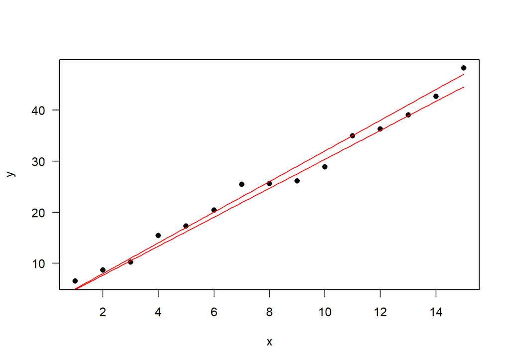

```r
plot(x, y, pch = 16, las = 1)
curve(przedzial[1] * x + 2, col = "red", add = TRUE)
curve(przedzial[2] * x + 2, col = "red", add = TRUE)
```

Widzimy, że otrzymany przedział ufności niezbyt dokładnie dopasowuje nachylenie do danych. ## Przykład 2

```r
x <- 1:25
y <- 4 * 1:25 + rnorm(15,5,6) + 2
```

```r
model <- lm(y~x)
przedzial <- pairs_bootstrap(x, y, 1000)
print(paste0("(", round(przedzial[1], 2), ", ", round(przedzial[2], 2), ")"))
```

```
## [1] "(9.98, 4)"
```

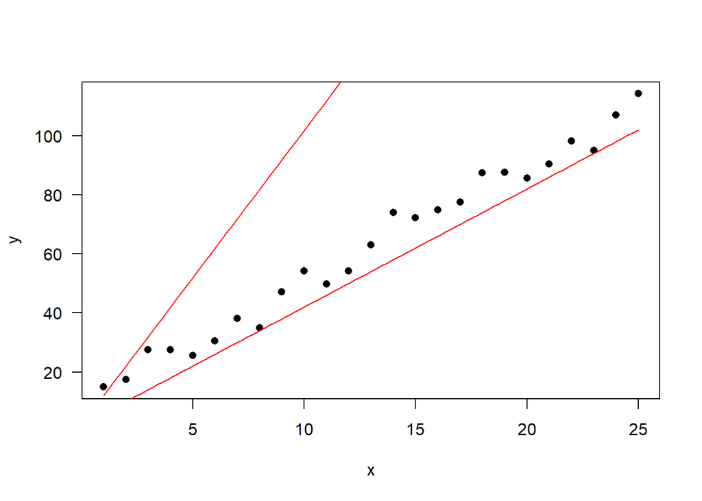

```r
plot(x, y, pch = 16, las = 1)
curve(przedzial[1] * x + 2, col = "red", add = TRUE)
curve(przedzial[2] * x + 2, col = "red", add = TRUE)
```

Tutaj również niezbyt dokładne jest dopasowanie.